# Initial Simulations

Tianyi Liu

2023-06-30

```r
# source("a01_extended_dSVA.R")
source("s02_simulation_functions.R")
library(extraDistr)
library(statmod)
library(MASS)
library(dplyr)
library(tidyr)
library(statmod)
set.seed(100)
```

The original dSVA model assumes
$$\mathbf{Y} = \mathbf{X}\mathbf{B} + \mathbf{Z}\mathbf{D} + \mathbf{E},$$
which can have two interpretations in the deconvolution context, depending on the orientation of $\mathbf{Y}$.

## Interpretation 1: Use Signature Matrix to Infer Proportions - Adjusting for Gene-wise Confounders

If we let $\mathbf{Y}$ be the $m \times n$ matrix as in the canonical deconvolution models, where $m$ is the number of genes and $n$ the number of samples, $\mathbf{X}$ is the signature matrix, and $\mathbf{B}$ the proportion matrix. Respectively, $\mathbf{Z}$ will be the matrix of gene-wise unadjusted confounders (since it has $m$ rows) and $\mathbf{D}$ the coefficients. Hence, using $\mathbf{\Theta}$ and $\mathbf{P}$ to denote the signature and proportion matrices, the dSVA model is rewritten as

$$\mathbf{Y} = \mathbf{\Theta}\mathbf{P} + \mathbf{Z}\mathbf{D} +
\mathbf{E}, \\
\mathbf{\Theta} \geq 0, \mathbf{P} \geq 0, \\
\mathbf{P}^T \mathbf{1} = \mathbf{1}.$$
This calls for using a constrained non-negative least square to solve for $\mathbf{P}$ in every regression step, which is available through the `pnnls()` function from the `lsei` package.

#### dSVA function: interpretation 1

```r
## Y: gene-by-sample bulk expression matrix (m x n)
## X: gene-by-cell type signature matrix (m x K), fully known
## q: the presumed number of confounders
dsva_ext <- function(Y, X, q) {
  n <- ncol(Y)
  m <- nrow(Y)

  ## step 1: obtain the residual when confounders Z are ignored
  B_star_hat <- apply(Y, 2, function(y) {lsei::pnnls(a = X, b = y, sum = 1)$x}) # solve a constrained NNLS
  U_x <- svd(X)$u
  M_x <- U_x %*% t(U_x) # projection matrix onto the column space of X
  R <- (diag(1, m) - M_x) %*% (Y - X %*% B_star_hat) # we project the residual to be orthogonal to X
  # norm(R, "F")/norm(Y - X %*% B_star_hat, "F")

  ## step 2: svd on the residual space; choose the first q left singular vectors
  U_q <- svd(R)$u[, seq(q)]

  ## step 3: estimate the surrogate variable
  Psi_hat <- apply(R, 2, function(r) {lsei::lsei(a = U_q, b = r)})
  M_jn <- matrix(1/n, n, n)
  D_jn <- diag(1, n) - M_jn
  Gamma_hat <- U_q + X %*% B_star_hat %*% D_jn %*% t(Psi_hat) %*% solve(Psi_hat %*% D_jn %*% t(Psi_hat))

  ## step 4: fitting the model again with the surrogate variable
  X_new <- cbind(Gamma_hat, X)
  B_hat <- apply(Y, 2, function(y) {lsei::pnnls(a = X_new, b = y, k = q, sum = 1)$x})
  P_hat <- B_hat[-seq(q), ]
  P_hat
}
```

#### Simulations

We use $m$ to denote the number of genes, $n$ the number of samples, $K$ the number of cell types, and $p$ the number of hidden confounders. $p_{\rm sig}$ is the average proportion of genes being markers, and expression of markers in the corresponding cell type is $\lambda$ times as high as in the rest of cell types. $\mu$ is the absolute mean of continuous confounding variables. Other parameters were assumed useful initially but haven’t been used in the final simulation. We perform $B$ different simulations.

```r
m <- 20
n <- 200
K <- 5
p <- 2
p_sig <- 0.5
p_class <- 0.5
rho <- 0.5
lambda <- 5
mu <- 1 # confounding variable means
# S <- 5
B <- 100
```

The simulations require generating a truth for each matrix component. They are generated via:

- $\mathbf{x}_j^T \sim \Xi \cdot \pi(W \cdot {\rm dir}(1, 1, \dots, 1) + (1 - W) \cdot {\rm dir}(\lambda, 1, \dots, 1) )$, where $\Xi \sim \chi^2_{200}$, $W \sim Ber(p_{\rm sig})$, and $\pi$ is a permutation operator;
- $\mathbf{z}_1 = (0, \dots. 0, 1, \dots, 1)^T$ ($m/2$ $0$s and $1$s each).
- $z_{j2} \sim I(j < m/2) \cdot N(-\mu, 100) + I(j \geq m/2) N(\mu, 100)$.
- $\mathbf{\alpha}_i \sim {\rm dir}(1, \dots, 1, \rho, \dots, \rho)$ ($K$ $1$s and $p$ $\rho$s);
- $\mathbf{p}_i \sim {\rm dir}(\alpha_{i1}, \dots, \alpha_{iK})$;
- $\mathbf{d}_i \sim N(\mathbf{0}, {\rm diag}(\alpha_{i(K + 1)}, \dots, \alpha_{i(K + p)}))$
- $\mathbf{e}_j^T \sim N(\mathbf{0}, S\mathbf{I}_n)$, wherw $S \sim IG(10, 9)$.

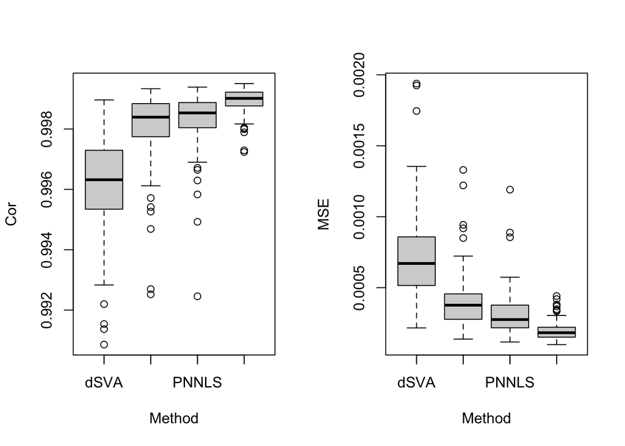

```r
result_matrix <- matrix(nrow = B, ncol = 8)

## run the simulation B times
for (b in 1:B) {
  true_data <- dSVA_deconv_gene(m, n, K, p, p_sig, p_class, rho, lambda, mu)
  P_dSVA <- dsva_ext(Y = true_data$Y, X = true_data$X, q = p)
  P_nnls <- apply(true_data$Y, 2, function(y) {lsei::nnls(a = true_data$X, b = y)$x})
  P_nnls <- apply(P_nnls, 2, function(x) x/sum(x))
  P_pnnls <- apply(true_data$Y, 2, function(y) {lsei::pnnls(a = true_data$X, b = y, sum = 1)$x})

  ## if we know both X and Z
  X_new = cbind(true_data$Z, true_data$X)
  P_hat <- apply(true_data$Y, 2, function(y) {lsei::pnnls(a = X_new, b = y, k = p, sum = 1)$x})[-seq(p), ]

  cor_dSVA <- mean(my_cor(true_data$P_star, P_dSVA))
  cor_nnls <- mean(my_cor(true_data$P_star, P_nnls))
  cor_pnnls <- mean(my_cor(true_data$P_star, P_pnnls))
  cor_best <- mean(my_cor(true_data$P_star, P_hat))

  mse_dSVA <- my_mse(true_data$P_star, P_dSVA)
  mse_nnls <- my_mse(true_data$P_star, P_nnls)
  mse_pnnls <- my_mse(true_data$P_star, P_pnnls)
  mse_best <- my_mse(true_data$P_star, P_hat)

  result_matrix[b, ] <- c(cor_dSVA, cor_nnls, cor_pnnls, cor_best, mse_dSVA, mse_nnls, mse_pnnls, mse_best)
}

result_df <- as_tibble(cbind(1:B, result_matrix))
colnames(result_df) <- c("b", "cor_dSVA", "cor_nnls", "cor_pnnls", "cor_known", "mse_dSVA", "mse_nnls", "mse_pnnls", "mse_known")

par(mfrow = c(1, 2))
boxplot(x = result_df$cor_dSVA, result_df$cor_nnls, result_df$cor_pnnls, result_df$cor_known, xlab = "Method", ylab = "Cor")
axis(1, at = c("1", "2", "3", "4"), labels = c("dSVA", "NNLS", "PNNLS", "Known"))
boxplot(result_df$mse_dSVA, result_df$mse_nnls, result_df$mse_pnnls, result_df$mse_known, xlab = "Method", ylab = "MSE")
axis(1, at = c("1", "2", "3", "4"), labels = c("dSVA", "NNLS", "PNNLS", "Known"))
```

#### Issues

Unlike when the coefficients are unconstrained, when sum-to-one on top of the non-negative constraints were imposed to estimating $\mathbf{P}$, the column space of the residual

$$\mathbf{R} = \mathbf{Y} - \mathbf{\Theta}\hat{\mathbf{P}}$$

isn’t usually orthogonal to $C(\mathbf{\Theta})$, as dSVA naturally assumes. In the algorithm, we only use the space in $C(\mathbf{R})$ that is orthogonal to $C(\mathbf{\Theta})$. It can probably invalidate further analysis in dSVA. Noticeably, the original model assume
$$\mathbf{Y} = \mathbf{\Theta}\mathbf{P} + \mathbf{Z}\mathbf{D} +
\mathbf{E},$$
where $\mathbb{E}[\mathbf{E}] = \mathbf{0}$. Whereas if we project the residual via

$$\mathbf{Y} = \mathbf{\Theta}\hat{\mathbf{P^*}} + \mathbf{R} \\
= \mathbf{\Theta}\hat{\mathbf{P^*}} + (\mathbf{I_m} -
\mathbf{M}_{\mathbf{\Theta}})\mathbf{R} +
\mathbf{M}_{\mathbf{\Theta}}\mathbf{R},$$

the “leftover” residual has $\mathbb{E}[\mathbf{M}_{\mathbf{\Theta}}\mathbf{R}] \neq \mathbf{0}$. This could largely be due to that $C(\mathbf{\Theta})$ isn’t orthogonal to $C(\mathbf{R})$.

```r
ls <- dSVA_deconv_gene(m, n, K, p, p_sig, p_class, rho, lambda, mu)
Y <- ls$Y
X <- ls$X
m <- nrow(Y)
n <- ncol(Y)

## step 1: obtain the canonical model residual
B_star_hat <- apply(Y, 2, function(y) {lsei::pnnls(a = X, b = y, sum = 1)$x})
R_star <- Y - X %*% B_star_hat
(t(X) %*% R_star)[, 1:10]
```

```
##       [,1]   [,2]  [,3] [,4]   [,5] [,6] [,7]   [,8] [,9] [,10]
## [1,] -12.4   6.85  -354  162 -924.7 -286 -129 -384.8 -292   987
## [2,] -12.4 422.90 -2561  554 -443.1 -286 -129   13.8 -292   634
## [3,] -12.4 422.90  -354  358   64.6 -286 -129   13.8 -292   451
## [4,] -12.4 422.90  -354  554   64.6 -822 -129   13.8 -292   987
## [5,] -12.4 107.25  -354  554 -368.7 -489 -542   13.8 -292   987
```

```r
U_x <- svd(X)$u
mean(U_x %*% t(U_x) %*%  R_star) # mean left-over residual value
```

```
## [1] -0.0628
```

Otherwise, we need the assumption that $C(\mathbf{\Theta}) \perp C(\mathbf{R})$, either non-asymptotically or asymptotically as $m \rightarrow \infty$.

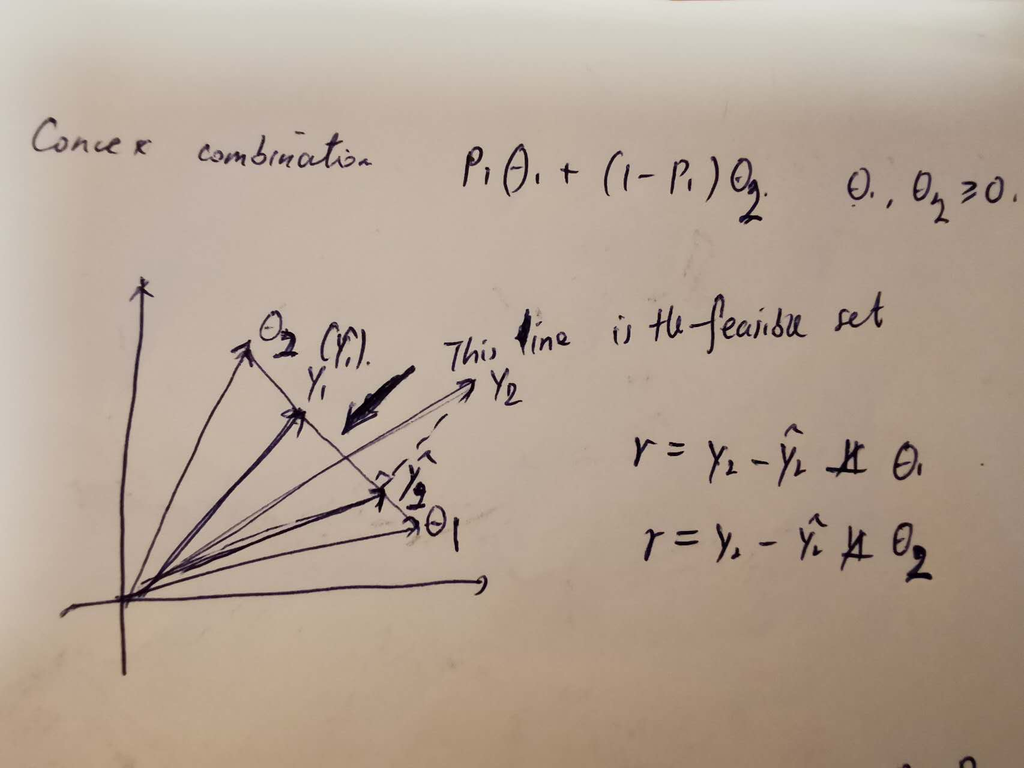

Why orthogonality of residuals fails in constrained NNLS case

However, barring some boundary conditions, this issue is half solved if we remove the sum-to-one constraint in this model, i.e. we use relative proportions, or we use the other interpretation of the dSVA model, to obtain the cell-type specific expression (see next).

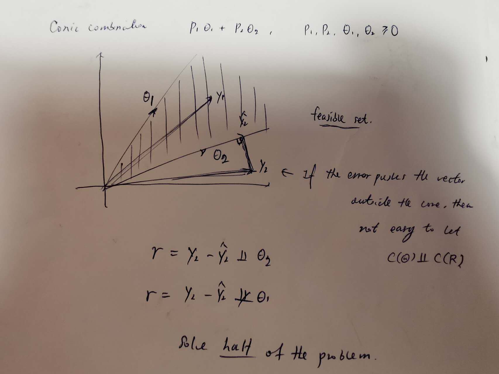

Why orthogonality of residuals may be half solved in NNLS case

This is only the case when $m = K = 2$, If we generalize the issue to higher dimensions, say we have $K = 2$ and $m = 200$, still only one of the orthogonality can be broken when $\mathbf{y}$ falls outside the cone once projected to the two dimensional plane spanned by $(\mathbf{\theta}_1, \mathbf{\theta}_2)$. There are conditions though, that this could be solved. For example, $m = K = 2$, $\mathbf{\theta}_1 = (c_1, 0)^T$, $\mathbf{\theta}_2 = (0, c_2)^T$, this issue is solved. In higher dimension cases, this means that a $\mathbf{\theta}_1$ and $\mathbf{\theta}_2$ span a 2-dimensional positive orthant of $\mathbb{R}^m$.

### Reomve the sum-to-one constraint when solving for $\mathbf{P}$.

```r
dsva_ext_nn <- function(Y, X, q) {
  n <- ncol(Y)
  m <- nrow(Y)

  ## step 1: obtain the residual when confounders Z are ignored
  B_star_hat <- apply(Y, 2, function(y) {lsei::nnls(a = X, b = y)$x}) # solve an NNLS
  U_x <- svd(X)$u
  M_x <- U_x %*% t(U_x) # projection matrix onto the column space of X
  R <- (diag(1, m) - M_x) %*% (Y - X %*% B_star_hat) # we project the residual to be orthogonal to X
  # norm(R, "F")/norm(Y - X %*% B_star_hat, "F")

  ## step 2: svd on the residual space; choose the first q left singular vectors
  U_q <- svd(R)$u[, seq(q)]

  ## step 3: estimate the surrogate variable
  Psi_hat <- apply(R, 2, function(r) {lsei::lsei(a = U_q, b = r)})
  M_jn <- matrix(1/n, n, n)
  D_jn <- diag(1, n) - M_jn
  Gamma_hat <- U_q + X %*% B_star_hat %*% D_jn %*% t(Psi_hat) %*% solve(Psi_hat %*% D_jn %*% t(Psi_hat))

  ## step 4: fitting the model again with the surrogate variable
  X_new <- cbind(Gamma_hat, X)
  B_hat <- apply(Y, 2, function(y) {lsei::pnnls(a = X_new, b = y, k = q, sum = NULL)$x})
  P_tilde <- B_hat[-seq(q), ]
  P_hat <- apply(P_tilde, 2, function(x) x/sum(x))
  P_hat
}
```

Let us see whether the orthogonal residual has been improved

```r
ls <- dSVA_deconv_gene(m, n, K, p, p_sig, p_class, rho, lambda, mu)
Y <- ls$Y
X <- ls$X
m <- nrow(Y)
n <- ncol(Y)

## step 1: obtain the canonical model residual
B_star_hat <- apply(Y, 2, function(y) {lsei::nnls(a = X, b = y)$x})
# B_star_hat <- apply(B_star_hat, 2, function(b) b/sum(b))
R_star <- Y - X %*% B_star_hat
(t(X) %*% R_star)[, 1:10]
```

```
##           [,1]      [,2]      [,3]      [,4]      [,5]      [,6]      [,7]
## [1,] -3.19e+02  5.83e-13 -2.04e+03 -7.02e+02 -1.02e-11 -2.77e+03 -7.74e-12
## [2,]  1.05e-11  1.51e-12 -5.46e-12  4.83e-13 -4.32e-12 -4.09e-12 -9.45e-12
## [3,] -9.36e+01 -4.37e+02 -5.07e-12 -1.16e-12 -1.33e+03 -2.40e-12 -6.47e-12
## [4,] -4.21e+02  9.44e-13 -1.43e+03 -6.78e+02 -5.43e-12 -2.09e+03 -1.29e-11
## [5,] -6.93e+01  2.49e-12 -1.48e-11 -1.72e-12 -8.70e-12 -2.50e-12 -1.26e-11
##           [,8]      [,9]     [,10]
## [1,] -1.61e-11 -1.18e-11 -9.66e+02
## [2,] -2.12e-11 -7.61e+01 -2.52e-12
## [3,] -2.88e+03 -1.52e+03 -7.32e-12
## [4,] -1.97e-11 -1.55e-11 -3.66e-12
## [5,] -2.18e+02 -2.16e-11  2.15e-12
```

```r
U_x <- svd(X)$u
mean(U_x %*% t(U_x) %*%  R_star) # mean left-over residual value
```

```
## [1] -0.33
```

The mean residual has not been reduced closer to 0 (because we did not fit these parameters according to the new model), although the orthogonality has improved in some directions.

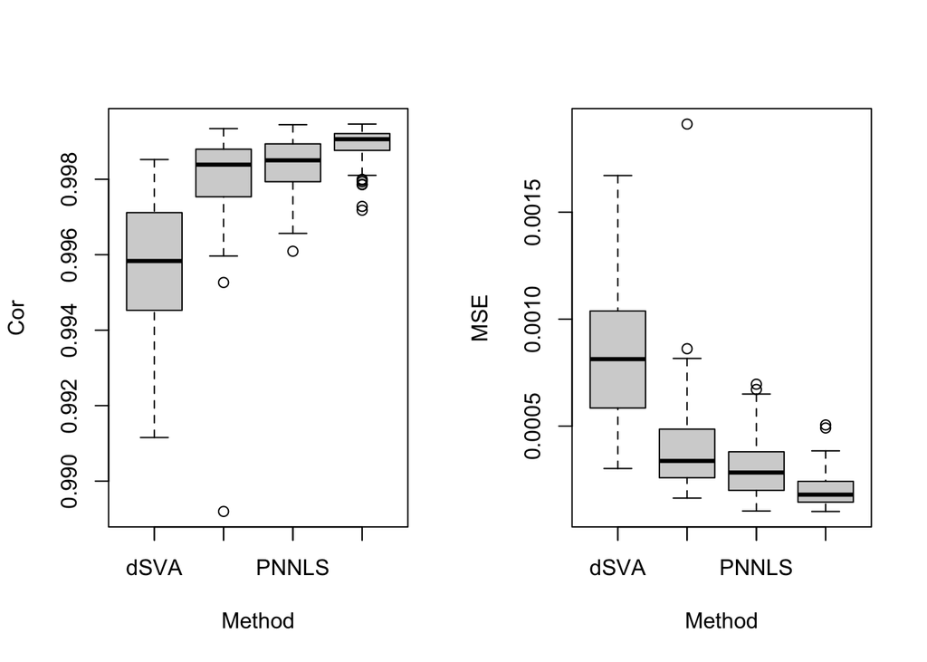

```r
result_matrix <- matrix(nrow = B, ncol = 8)

## run the simulation B times
for (b in 1:B) {
  true_data <- dSVA_deconv_gene(m, n, K, p, p_sig, p_class, rho, lambda, mu)
  P_dSVA <- dsva_ext_nn(Y = true_data$Y, X = true_data$X, q = p)
  P_nnls <- apply(true_data$Y, 2, function(y) {lsei::nnls(a = true_data$X, b = y)$x})
  P_nnls <- apply(P_nnls, 2, function(x) x/sum(x))
  P_pnnls <- apply(true_data$Y, 2, function(y) {lsei::pnnls(a = true_data$X, b = y, sum = 1)$x})

  ## if we know both X and Z
  X_new = cbind(true_data$Z, true_data$X)
  P_hat <- apply(true_data$Y, 2, function(y) {lsei::pnnls(a = X_new, b = y, k = p, sum = 1)$x})[-seq(p), ]

  cor_dSVA <- mean(my_cor(true_data$P_star, P_dSVA))
  cor_nnls <- mean(my_cor(true_data$P_star, P_nnls))
  cor_pnnls <- mean(my_cor(true_data$P_star, P_pnnls))
  cor_best <- mean(my_cor(true_data$P_star, P_hat))

  mse_dSVA <- my_mse(true_data$P_star, P_dSVA)
  mse_nnls <- my_mse(true_data$P_star, P_nnls)
  mse_pnnls <- my_mse(true_data$P_star, P_pnnls)
  mse_best <- my_mse(true_data$P_star, P_hat)

  result_matrix[b, ] <- c(cor_dSVA, cor_nnls, cor_pnnls, cor_best, mse_dSVA, mse_nnls, mse_pnnls, mse_best)
}

result_df <- as_tibble(cbind(1:B, result_matrix))
colnames(result_df) <- c("b", "cor_dSVA", "cor_nnls", "cor_pnnls", "cor_known", "mse_dSVA", "mse_nnls", "mse_pnnls", "mse_known")

par(mfrow = c(1, 2))
boxplot(x = result_df$cor_dSVA, result_df$cor_nnls, result_df$cor_pnnls, result_df$cor_known, xlab = "Method", ylab = "Cor")
axis(1, at = c("1", "2", "3", "4"), labels = c("dSVA", "NNLS", "PNNLS", "Known"))
boxplot(result_df$mse_dSVA, result_df$mse_nnls, result_df$mse_pnnls, result_df$mse_known, xlab = "Method", ylab = "MSE")
axis(1, at = c("1", "2", "3", "4"), labels = c("dSVA", "NNLS", "PNNLS", "Known"))
```

#### Issue 2

Another issue is that, while there might be variation in the residuals orthogonal to $C(\mathbf{\Theta})$ that can be explained by the hidden confounders, the large scale difference between $\mathbf{\Theta}$ and $\mathbf{P}$ will absorb the need for this correction from plainly using the NNLS or constrained NNLS algorithms. What if, as in some cases, each gene is normalized to have a total expression 1 in all $K$ cell types in the given signature matrix?

#### Rescale each row of $\mathbf{Theta}$ to have a sum of one:

First we row-scale the signature matrix. I think this almost gives way to the CAM method.

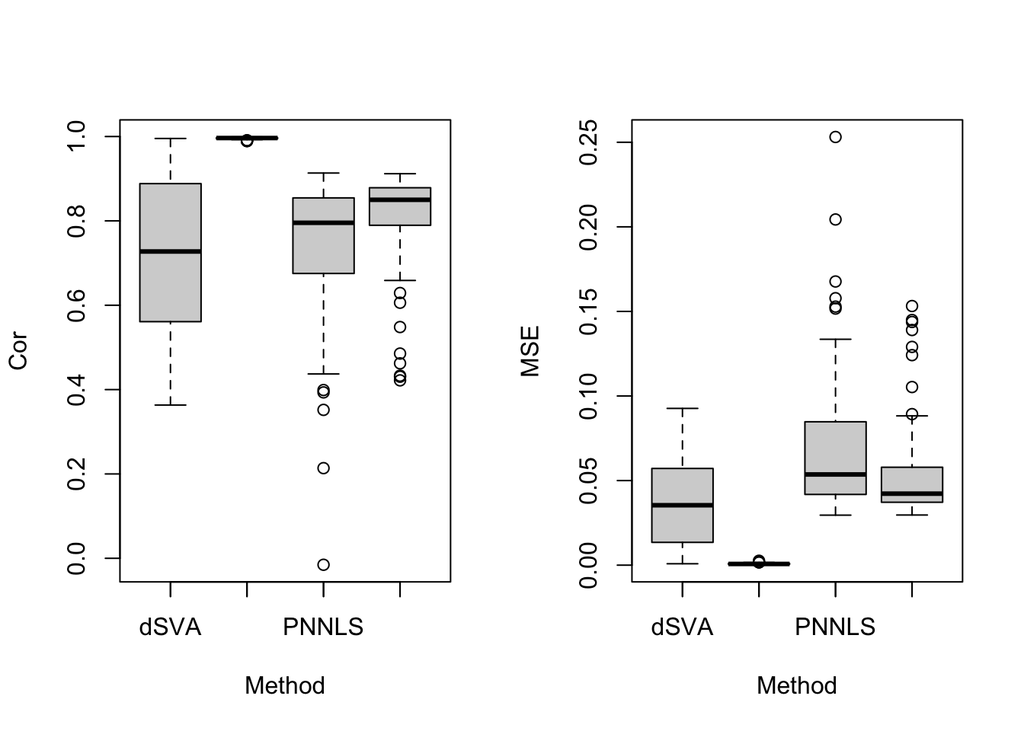

```r
result_matrix <- matrix(nrow = B, ncol = 8)

## run the simulation B times
for (b in 1:B) {
  true_data <- dSVA_deconv_gene(m, n, K, p, p_sig, p_class, rho, lambda, mu)
  X_rs <- t(apply(true_data$X, 1, function(x) x/sum(x)))
  P_dSVA <- dsva_ext_nn(Y = true_data$Y, X = X_rs, q = p)
  P_nnls <- apply(true_data$Y, 2, function(y) {lsei::nnls(a = X_rs, b = y)$x})
  P_nnls <- apply(P_nnls, 2, function(x) x/sum(x))
  P_pnnls <- apply(true_data$Y, 2, function(y) {lsei::pnnls(a = X_rs, b = y, sum = 1)$x})

  ## if we know both X and Z
  X_new = cbind(true_data$Z, X_rs)
  P_hat <- apply(true_data$Y, 2, function(y) {lsei::pnnls(a = X_new, b = y, k = p, sum = 1)$x})[-seq(p), ]

  cor_dSVA <- mean(my_cor(true_data$P_star, P_dSVA))
  cor_nnls <- mean(my_cor(true_data$P_star, P_nnls))
  cor_pnnls <- mean(my_cor(true_data$P_star, P_pnnls))
  cor_best <- mean(my_cor(true_data$P_star, P_hat))

  mse_dSVA <- my_mse(true_data$P_star, P_dSVA)
  mse_nnls <- my_mse(true_data$P_star, P_nnls)
  mse_pnnls <- my_mse(true_data$P_star, P_pnnls)
  mse_best <- my_mse(true_data$P_star, P_hat)

  result_matrix[b, ] <- c(cor_dSVA, cor_nnls, cor_pnnls, cor_best, mse_dSVA, mse_nnls, mse_pnnls, mse_best)
}

result_df <- as_tibble(cbind(1:B, result_matrix))
colnames(result_df) <- c("b", "cor_dSVA", "cor_nnls", "cor_pnnls", "cor_known", "mse_dSVA", "mse_nnls", "mse_pnnls", "mse_known")

par(mfrow = c(1, 2))
boxplot(x = result_df$cor_dSVA, result_df$cor_nnls, result_df$cor_pnnls, result_df$cor_known, xlab = "Method", ylab = "Cor")
axis(1, at = c("1", "2", "3", "4"), labels = c("dSVA", "NNLS", "PNNLS", "Known"))
boxplot(result_df$mse_dSVA, result_df$mse_nnls, result_df$mse_pnnls, result_df$mse_known, xlab = "Method", ylab = "MSE")
axis(1, at = c("1", "2", "3", "4"), labels = c("dSVA", "NNLS", "PNNLS", "Known"))
```

#### Rescale each column of $\mathbf{Theta}$ to have a sum of one:

Then, we column-scale the signature matrix.

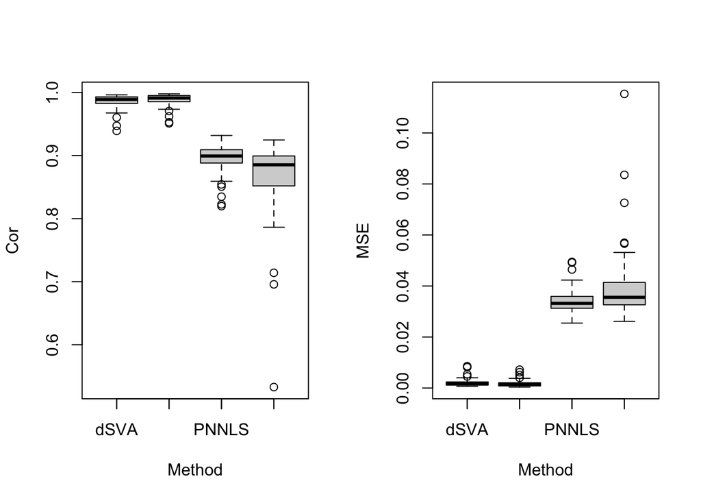

```r
result_matrix <- matrix(nrow = B, ncol = 8)

## run the simulation B times
for (b in 1:B) {
  true_data <- dSVA_deconv_gene(m, n, K, p, p_sig, p_class, rho, lambda, mu)
  X_cs <- apply(true_data$X, 2, function(x) x/sum(x))
  P_dSVA <- dsva_ext_nn(Y = true_data$Y, X = X_cs, q = p)
  P_nnls <- apply(true_data$Y, 2, function(y) {lsei::nnls(a = X_cs, b = y)$x})
  P_nnls <- apply(P_nnls, 2, function(x) x/sum(x))
  P_pnnls <- apply(true_data$Y, 2, function(y) {lsei::pnnls(a = X_cs, b = y, sum = 1)$x})

  ## if we know both X and Z
  X_new = cbind(true_data$Z, X_cs)
  P_hat <- apply(true_data$Y, 2, function(y) {lsei::pnnls(a = X_new, b = y, k = p, sum = 1)$x})[-seq(p), ]

  cor_dSVA <- mean(my_cor(true_data$P_star, P_dSVA))
  cor_nnls <- mean(my_cor(true_data$P_star, P_nnls))
  cor_pnnls <- mean(my_cor(true_data$P_star, P_pnnls))
  cor_best <- mean(my_cor(true_data$P_star, P_hat))

  mse_dSVA <- my_mse(true_data$P_star, P_dSVA)
  mse_nnls <- my_mse(true_data$P_star, P_nnls)
  mse_pnnls <- my_mse(true_data$P_star, P_pnnls)
  mse_best <- my_mse(true_data$P_star, P_hat)

  result_matrix[b, ] <- c(cor_dSVA, cor_nnls, cor_pnnls, cor_best, mse_dSVA, mse_nnls, mse_pnnls, mse_best)
}

result_df <- as_tibble(cbind(1:B, result_matrix))
colnames(result_df) <- c("b", "cor_dSVA", "cor_nnls", "cor_pnnls", "cor_known", "mse_dSVA", "mse_nnls", "mse_pnnls", "mse_known")

par(mfrow = c(1, 2))
boxplot(x = result_df$cor_dSVA, result_df$cor_nnls, result_df$cor_pnnls, result_df$cor_known, xlab = "Method", ylab = "Cor")
axis(1, at = c("1", "2", "3", "4"), labels = c("dSVA", "NNLS", "PNNLS", "Known"))
boxplot(result_df$mse_dSVA, result_df$mse_nnls, result_df$mse_pnnls, result_df$mse_known, xlab = "Method", ylab = "MSE")
axis(1, at = c("1", "2", "3", "4"), labels = c("dSVA", "NNLS", "PNNLS", "Known"))
```

## Interpretation 2: Use Proportions to Infer Cell-type Specific Expression - Adjusting for Sample-wise Confounders

This interpretation flips the bulk matrix into an $n \times m$ sample-by-gene matrix $\mathbf{Y}^T$. Correspondingly, the dSVA equation becomes one for estimating the cell-type specific expression for each gene, while the confounders $\mathbf{Z}$ become those regarding samples. This is the *original* configuration of dSVA.

$$\mathbf{Y}^T = \mathbf{P}^T\mathbf{\Theta}^T + \mathbf{Z}\mathbf{D} +
\mathbf{E}, \\
\mathbf{\Theta} \geq 0, \mathbf{P} \geq 0, \\
\mathbf{P}^T \mathbf{1} = \mathbf{1}.$$
The algorithm for estimating $\mathbf{\Theta}^T$ given $\mathbf{P}$ is given below.

```r
## Use dsva to impute cell-type specific expression adjusting for the hidden covariates
## X is the proportion matrix: each row represents a samples
dsva_ext2 <- function(Y, X, q) {
  n <- nrow(Y)
  m <- ncol(Y)

  ## step 1: obtain the canonical model residual
  B_star_hat <- apply(Y, 2, function(y) {lsei::nnls(a = X, b = y)$x})
  U_x <- svd(X)$u
  M_x <- U_x %*% t(U_x)
  # R <- Y - X %*% B_star_hat # challenge No.1: the residual space isn't orthogonal to columns of X
  R <- (diag(1, n) - M_x) %*% (Y - X %*% B_star_hat) # we project the residual to be orthogonal to X

  ## step 2: svd on the residual space
  U_q <- svd(R)$u[, seq(q)]

  ## step 3: estimate the surrogate variable
  Psi_hat <- apply(R, 2, function(r) {lsei::lsei(a = U_q, b = r)})
  M_jn <- matrix(1/m, m, m)
  D_jn <- diag(1, m) - M_jn
  Gamma_hat <- U_q + X %*% B_star_hat %*% D_jn %*% t(Psi_hat) %*% solve(Psi_hat %*% D_jn %*% t(Psi_hat))

  ## step 4: fitting the model again with the surrogate variable
  X_new <- cbind(Gamma_hat, X)
  B_hat <- apply(Y, 2, function(y) {lsei::pnnls(a = X_new, b = y, k = q, sum = NULL)$x})
  Theta_hat <- B_hat[-seq(q), ]
  Theta_hat
}
```

The simulation for truths is going to be a little different, The matrices are simulated mostly in the same way as above, except for

- $\mathbf{p}_i \sim {\rm dir}(\alpha_{i1}, \dots, \alpha_{iK})$;
- $\mathbf{d}_i \sim N(\mathbf{0}, {\rm diag}(\beta_{i1}, \dots, \beta_{ip}))$,

and that those vectors of length $n$ before are now of length $m$ and vice versa.

```r
n <- 20
m <- 200
K <- 5
p <- 2
p_sig <- 0.5
p_class <- 0.5
rho <- 0.5
lambda <- 5
mu <- 1 # confounding variable means
# S <- 5
B <- 100
```

First, let us see that the residual from Step 1 is indeed mostly orthogonal to $C(\mathbf{P}^T)$, and the residuals have a mean close to 0:

```r
ls <- dSVA_deconv_sim_people(m, n, K, p, p_sig, p_class, rho, lambda, mu)
Y <- ls$Y
X <- ls$P
n <- nrow(Y)
m <- ncol(Y)

## step 1: obtain the canonical model residual
B_star_hat <- apply(Y, 2, function(y) {lsei::nnls(a = X, b = y)$x})
# B_star_hat2 <- apply(Y, 2, function(y) {lsei::lsei(a = X, b = y)})
# B_star_hat <- apply(Y, 2, function(y) {lsei::nnls(a = X, b = y)$x})
R_star <- Y - X %*% B_star_hat
(t(X) %*% R_star)[, 1:10]
```

```
##           [,1]      [,2]      [,3]      [,4]      [,5]      [,6]      [,7]
## [1,] -7.68e-06 -2.11e-06 -3.81e-21 -1.80e-05 -5.97e-20 -1.13e-06 -1.42e-20
## [2,]  2.87e-14 -3.74e-14  1.90e-14 -9.96e-15 -7.61e-14 -9.76e-15 -1.92e+00
## [3,]  7.34e-14 -2.20e-13  1.56e-14 -3.25e-14 -2.56e-13 -1.55e-14 -8.13e-14
## [4,]  2.49e-14 -5.77e-15 -2.22e-14 -4.17e-14 -4.53e-14 -6.22e-15 -1.89e-15
## [5,]  1.35e-13 -4.59e-14  6.16e-15 -1.78e-14 -1.12e-13  1.81e-14 -2.07e-14
##           [,8]      [,9]     [,10]
## [1,] -1.94e-19 -5.08e-21  2.38e-20
## [2,] -2.95e-14  3.95e-15 -3.52e-15
## [3,] -1.14e-13 -4.02e-16 -2.75e-14
## [4,] -6.55e-14  1.95e-14 -5.00e-15
## [5,] -1.49e-13  1.71e-15  2.23e-15
```

```r
U_x <- svd(X)$u
mean(U_x %*% t(U_x) %*%  R_star) # mean left-over residual value
```

```
## [1] -0.0147
```

```r
# norm(t(X) %*% R_star, "F")^2/(ncol(X) * nrow(R_star)) # the frobenius norm of R
```

This situation is clearly more ideal.

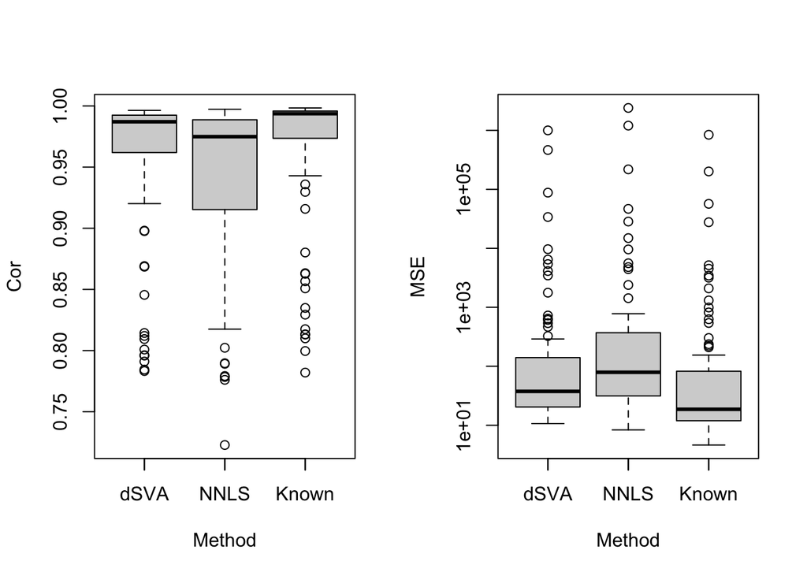

```r
result_matrix <- matrix(nrow = B, ncol = 6)
ab_list <- list()
bb <- 1 # counting for abnormal outputs
for (b in 1:B) {
  true_data <- dSVA_deconv_sim_people(m, n, K, p, p_sig, p_class, rho, lambda, mu)
  X_dSVA <- dsva_ext2(Y = true_data$Y, X = true_data$P, q = p)
  X_nnls <- apply(true_data$Y, 2, function(y) {lsei::nnls(a = true_data$P, b = y)$x})
  # X_pnnls <- apply(true_data$Y, 2, function(y) {lsei::pnnls(a = true_data$P, b = y, sum = 1)$x})

  ## if we know both X and Z
  P_new = cbind(true_data$Z, true_data$P)
  X_hat <- apply(true_data$Y, 2, function(y) {lsei::pnnls(a = P_new, b = y, k = p, sum = NULL)$x})[-seq(p), ]

  cor_dSVA <- mean(my_cor(t(true_data$X_star), t(X_dSVA)))
  cor_nnls <- mean(my_cor(t(true_data$X_star), t(X_nnls)))
  # cor_pnnls <- mean(my_cor(true_data$P_star, P_pnnls))
  cor_best <-  mean(my_cor(t(true_data$X_star), t(X_hat)))

  mse_dSVA <- my_mse(true_data$X_star, X_dSVA)
  mse_nnls <- my_mse(true_data$X_star, X_nnls)
  # mse_pnnls <- my_mse(true_data$P_star, P_pnnls)
  mse_best <- my_mse(true_data$X_star, X_hat)

  if (mse_best > 1e6) {
    result_matrix[b, ] <- rep(NaN, 6)
    ab_list[[bb]] <- true_data
    bb <- bb + 1
  } else {
    result_matrix[b, ] <- c(cor_dSVA, cor_nnls, cor_best, mse_dSVA, mse_nnls, mse_best)
  }
}

result_df <- as_tibble(cbind(1:B, result_matrix))
colnames(result_df) <- c("b", "cor_dSVA", "cor_nnls", "cor_known", "mse_dSVA", "mse_nnls", "mse_known")

par(mfrow = c(1, 2))
boxplot(x = result_df$cor_dSVA, result_df$cor_nnls, result_df$cor_known, xlab = "Method", ylab = "Cor", subset = result_df$mse_known < 1e6)
axis(1, at = c("1", "2", "3"), labels = c("dSVA", "NNLS", "Known"))
boxplot(result_df$mse_dSVA, result_df$mse_nnls, result_df$mse_known, xlab = "Method", ylab = "MSE", subset = result_df$mse_known < 1e6, log = "y")
axis(1, at = c("1", "2", "3"), labels = c("dSVA", "NNLS", "Known"))
```

There are some runs that do not converge, the reasons of which I am not sure at the moment.